# Kevin Martin CIS700 - Monday @ 8:00pm EST

Assessment 2

# 1. Data Setup

Dataset found here: https://www.kaggle.com/georgezakharov/historical-data-on-the-trading-of-cryptocurrencies/kernels

For Assessment 2, I am seeking to identify the most important feature for price prediction, as well as begin to test out some usable models. The target attribute is price_usd, which represents the price of a security on a given day, in USD. As such, I will be attempting to predict the price for a security given the available data. To help streamline the process, I will be using Bitcoin at first. Bitcoin is the most widely traded and active crytpocurrency, so the data is generally the cleanest and easiest to work with.

Building off of the results of Assessment 1, I have cleaned the data in the first couple of cells so I can get right into the next section.

As a quick summary, I have first imported all the modules I have been using/testing. As I've gone through, I've had to remove less effective approaches, so not all imported functions are used. Next, I loaded my dataset as a pandas dataframe, removed the completely irrelevant columns, and deleted missing (NaN) values. After Assessment 1, I noted that the major coins did not have much missing data, so removing the missing values kept their records intact. The lesser/more obscure coins were mostly affected, which is fine for this purpose.

I also printed out a couple of relevent metrics to show where the dataframe starts, as well as a distribution to show how the "major" cryptocurrencies compare to the minor ones.

```python
#python libararies
import pandas as pd
import matplotlib.pyplot as plt
%matplotlib inline
import numpy as np
import seaborn as sns
import warnings
warnings.filterwarnings("ignore")
from numpy import nan
from scipy import stats
import matplotlib.pyplot as plt
from matplotlib.pyplot import figure
from sklearn import decomposition, datasets
from sklearn import tree
from sklearn.pipeline import Pipeline
from sklearn.metrics import roc_auc_score
from sklearn import metrics
from sklearn.preprocessing import StandardScaler
from sklearn.linear_model import LogisticRegression
from sklearn.tree import DecisionTreeClassifier
from sklearn.metrics import confusion_matrix
from sklearn.metrics import accuracy_score
from sklearn.naive_bayes import GaussianNB
from sklearn.neighbors import KNeighborsClassifier
from sklearn.ensemble import GradientBoostingClassifier
from sklearn.ensemble import RandomForestClassifier
from sklearn.model_selection import train_test_split, GridSearchCV
from keras.models import Sequential
from keras.layers import LSTM,Dense,Dropout,AveragePooling1D,Reshape
from plotly.subplots import make_subplots
import plotly.graph_objects as go
import xgboost as xgb
from keras.models import Sequential
from keras.layers import Dense
from sklearn.metrics import mean_squared_error as mse
from sklearn.ensemble import GradientBoostingRegressor
from sklearn.inspection import plot_partial_dependence

#load my dataset as a pandas dataframe
path = '/home/kebin/Syracuse/Syracuse/CIS700/Assignment1/crypto.csv'
df =  pd.read_csv(path, sep=',')

#clean dataset by dropping unnecessary columns, missing values, and adding a binary 'IsBit' flag
del_col_list = ['site_url', 'github_url', 'platform_name', 'industry_name', 'crypto_type']
df.drop(del_col_list, axis=1, inplace=True)
df.dropna(inplace=True)
df['IsBit'] = np.where(df['ticker']=='BTC',1,0)
print(df.shape)
df.info()
```

```
(410653, 13)
<class 'pandas.core.frame.DataFrame'>
Int64Index: 410653 entries, 0 to 1818104
Data columns (total 13 columns):
 #   Column                       Non-Null Count   Dtype
---  ------                       --------------   -----
 0   trade_date                   410653 non-null  object
 1   volume                       410653 non-null  float64
 2   price_usd                    410653 non-null  float64
 3   price_btc                    410653 non-null  float64
 4   market_cap                   410653 non-null  float64
 5   capitalization_change_1_day  410653 non-null  float64
 6   USD_price_change_1_day       410653 non-null  float64
 7   BTC_price_change_1_day       410653 non-null  float64
 8   crypto_name                  410653 non-null  object
 9   ticker                       410653 non-null  object
 10  max_supply                   410653 non-null  float64
 11  minable                      410653 non-null  float64
 12  IsBit                        410653 non-null  int64
dtypes: float64(9), int64(1), object(3)
memory usage: 43.9+ MB
```

```python
# I will be focuing bitcoin, and using the btc_data data frame
btc_data = df[df['ticker']=='BTC']
print(btc_data.shape[0])
```

```
1554
```

```python
df['ticker'].value_counts()
```

```
LBTC    1759
FTC     1554
LTC     1554
XRP     1554
BTC     1554
        ...
CELC      11
BTCR      11
IBS       10
SCOP       6
HPAY       4
Name: ticker, Length: 637, dtype: int64
```

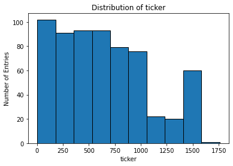

```python
# Histogram
def hist_chart(df, col):
        plt.hist(df[col].value_counts(), edgecolor = 'k');
        plt.xlabel(col); plt.ylabel('Number of Entries');
        plt.title('Distribution of '+col);
        plt.show()


hist_chart(df, 'ticker')
```

# 2. Correlations

To get a general sense of corrleations, a heatmap across all vairables as compared to all others was generated. This was a nice visual aid, but not really helpful to make actual decisions. Next I ran the correlations to the target attribute, price_usd.

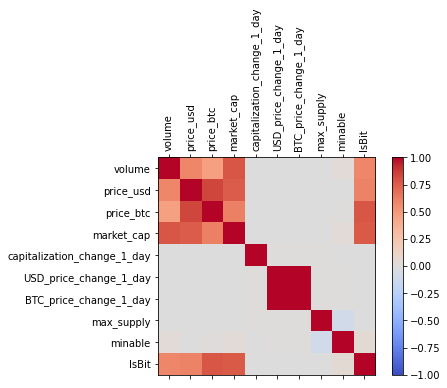

```python
%matplotlib inline
graph_df = df.select_dtypes(exclude="object")
corr = graph_df.corr()
fig = plt.figure()
ax = fig.add_subplot(111)
cax = ax.matshow(corr,cmap='coolwarm', vmin=-1, vmax=1)
fig.colorbar(cax)
ticks = np.arange(0, len(graph_df.columns),1)
ax.set_xticks(ticks)
plt.xticks(rotation=90)
ax.set_yticks(ticks)
ax.set_xticklabels(graph_df.columns)
ax.set_yticklabels(graph_df.columns)
plt.show()
```

```python
corr_data2 = df[df.columns[1:]].corr()['price_usd'][:]
sorted_corr_data2 = corr_data2.sort_values(kind="quicksort")
print(sorted_corr_data2)
```

```
max_supply                    -0.006573
minable                       -0.004673
USD_price_change_1_day        -0.000761
BTC_price_change_1_day        -0.000760
capitalization_change_1_day   -0.000183
volume                         0.589624
IsBit                          0.605991
market_cap                     0.759805
price_btc                      0.838757
price_usd                      1.000000
Name: price_usd, dtype: float64
```

# 3. Feature Selection

Here I can really start getting some useful information out of the data. In my past experience with feature selection, I noted that gradient boosting generally yielded the best results. I believe this to be due to the higher amount of hyper parameters available for tuning. Furthermore, I came across a package none as XGBoost, which is sort of a "pre-optimized" gradient boosting method. While there are still parameters to train, the core algorithm already comes ready to run. Additionally, there are more functions built around it, and one in particular (DMatrix) is very useful for selecting feature importance. It is also specifically built for numerical data, and as the target attribute is numeric, this approach is very appropriate.

I also graphed out both their correlation to price_usd, as well as the partial dependencies. Because I trust the results of the XGBoost approach, these were purely for visual representations, but I think it is worthwhile to show.

Finally, I'm using a btc_data data frame that selectus just the Bitcoin records. This will help make the models more focused during testing.

```python
btc_data = df[df['ticker']=='BTC']
```

```python
final_vars = ['volume', 'market_cap', 'capitalization_change_1_day', 'max_supply', 'minable']
train_y = btc_data.price_usd.values
train_X = btc_data[final_vars]
xgb_params = {
    'eta': 0.05,
    'max_depth': 10,
    'subsample': 1.0,
    'colsample_bytree': 0.7,
    'objective': 'reg:linear',
    'eval_metric': 'rmse',
    'silent': 1
}
dtrain = xgb.DMatrix(train_X, train_y, feature_names=train_X.columns.values)
model = xgb.train(dict(xgb_params, silent=1), dtrain, num_boost_round=100)
remain_num = 99
```

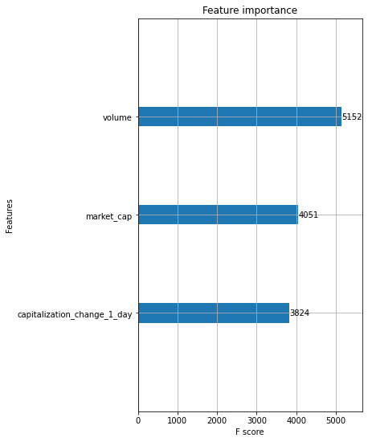

```python
fig, ax = plt.subplots(figsize=(5,9))
xgb.plot_importance(model, max_num_features=remain_num, height=0.2, ax=ax)
plt.show()
```

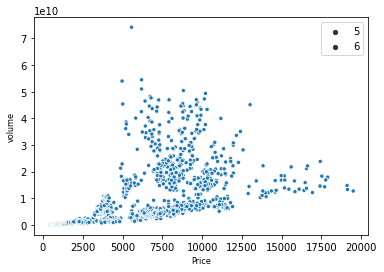

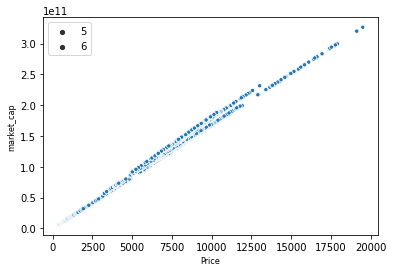

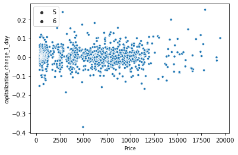

```python
xgb_vars = ['volume', 'market_cap', 'capitalization_change_1_day']
for f in [x for x in xgb_vars]:
    sns.scatterplot(y=btc_data[f].values, x=btc_data.price_usd.values, size=6)
    plt.xlabel('Price', fontsize=8)
    plt.ylabel(f, fontsize=8)
    plt.show()
```

For additional support, the sugested partial plots of the three most important features. Note that I used a generic gradient boosting model simply to help visualize. However I believe this method was not as helpful as the above scatter plots.

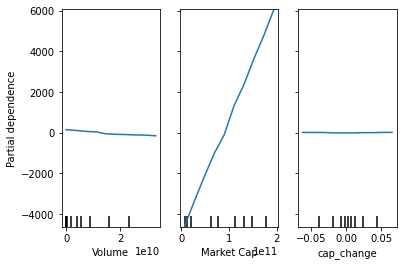

```python
y = btc_data.price_usd
X = btc_data[xgb_vars]
my_model = GradientBoostingRegressor()
my_model.fit(X, y)
my_plots = plot_partial_dependence(my_model,
                                   features=[0, 1, 2], # column numbers of plots we want to show
                                   X=X,            # raw predictors data.
                                   feature_names=['Volume', 'Market Cap', 'cap_change'], # labels on graphs
                                   grid_resolution=10,
                                   target='price_usd') # number of values to plot on x axis
```

# 4. Time Series Analysis

To help in predicting the next day's price, I will be employing a time series strategy. Thus far, I have been very happy with a sequential nerual network, which is implemented through Keras (using the standard Tensor Flow backend). This approach is beneficial because it is set up for a situation where each layer has one input node and one output node, with a linear focus. So this method would not work with a multi-branching approach or residual connections. In the case of pricing data, we specifically have only one input and one output per layer, and we actually want a linear output.

The other benefit is that it is not (relatively) computationally intesive. Due to the linear nature, it is very quick to generate a multi-layered neural network. On a mid-range CPU, I am able to run 250 iterations in seconds. This generates a comprehensive look at the data in a very short time.

Before getting to the sequential neural network,I wanted to show a couple of other approaches as a comparison. The cell below has the driver function, which splits the data between a train/test amount (using 70% train/30% test) as well as a graph helper function. I'm showing the basic average only as an example of the driver data, its "result" is completely useless.

Next I included a basic moving average approach which yielded more benefit than I would have initially thought. First, the results were, at least visually, somewhat close to the actual price. At least the general trend of up or down was followed, and save for some larger price moves the overall direction of the price was maintained. Second, this helped support my train/test decision: if the moving average was on the right track, then I believe to have a great starting point for the neural network.

```python
time_data = btc_data['price_usd']
total = df[df.ticker=='BTC'].shape[0]
test = int(round(total * .3))
train = total - test
buff = 80

prev_values = time_data.iloc[:1200]
y_train3 = time_data[buff:train]
y_test3 = time_data[train:]
X_train3 = pd.DataFrame([list(time_data[i:i+buff]) for i in range(train - buff)],
                       columns=range(buff,0,-1),index=y_train3.index)
X_test3 = pd.DataFrame([list(time_data[i:i+buff]) for i in range(train - buff,total - buff)],
                       columns=range(buff,0,-1),index=y_test3.index)

def plot_pred(pred,title):
    plt.figure(figsize=(17,5))
    plt.plot(prev_values,label='Train')
    plt.plot(y_test3,label='Actual')
    plt.plot(pred,label='Predicted')
    plt.ylabel("Stock prices")
    plt.title(title,fontsize=20)
    plt.legend()
    plt.show()
```

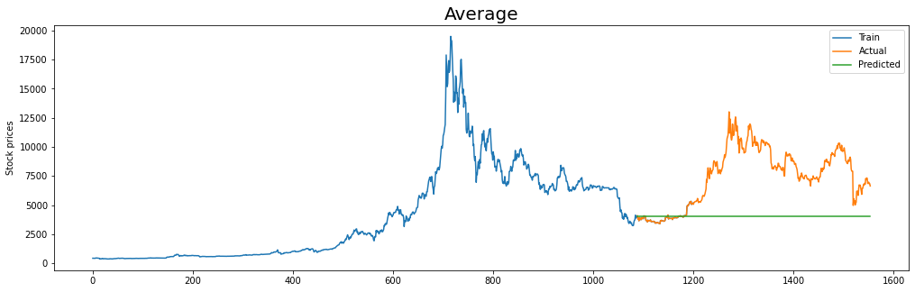

```python
# First, as a baseline, simple average
y_av = pd.Series(np.repeat(prev_values.mean(),test),index=y_test3.index)
plot_pred(y_av,"Average")
```

[output not shown]

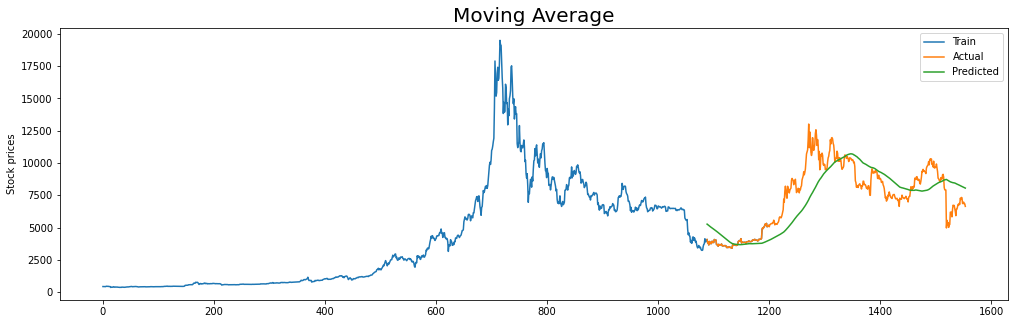

```python
# Next, as a non-linear approach, the moving average
y_ma = X_test3.mean(axis=1)
print(mse(y_ma,y_test3))
plot_pred(y_ma,"Moving Average")
```

[output not shown]

```python
%%capture
ma_nn = Sequential([Dense(64,input_shape=(buff,),activation='relu'),Dense(32,activation='linear'),Dense(1)])
ma_nn.compile(loss='mse',optimizer='rmsprop',metrics=['mae','mse'])
history = ma_nn.fit(X_train3, y_train3, epochs=250, batch_size=32, validation_split=0.25)
y_nn = ma_nn.predict(X_test3)
y_nn = pd.Series(y_nn[:,0],index=y_test3.index)
```

[output not shown]

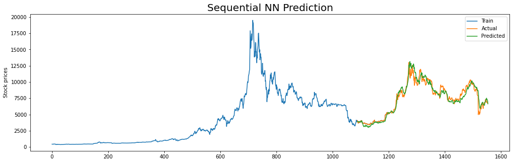

```python
print("%.2f" % mse(y_nn,y_test3))
plot_pred(y_nn,"Sequential NN Prediction")
```

[output not shown]

# 5. Next Steps - Milestone 3

So far, I have extracted the three most important features as well as found a pretty good neural network to help with the time series aspect. This has actually helped answer my first stated goal from milestone 1:

Which features of cryptocurrency trading will best predict future price movements, and can we we further predict the magnitude of such movements?

My second research question from Assessment 1 is: Given the variety of features across time, can we find an optimal combination to predict the future price movements? To answer this, I am going to combine the top three features with the time series model. In this way, I'm hoping to get the price prediction even tighter, and have less variance on the outliers or extra volatile trading days. By looking more closely at the graph, we can see that on days with large spikes or drops, the variance is more pronounced. So hopefullyt his approach will remove some of that noise.

Finally, I will apply the ending model to a couple more cryptocurrencies to really see how accurate the approach is. Thus far, I have focused on Bitcoin to help make the data more manageable. However, a side effect of that is only focusing on the most popular and widely traded coin. My fear is that other currencies won't behave the same way, and this approach **may** only be suitable for Bitcoin. On the other hand, they are all quite volatile and some of the other more popular coins should exhibit much of the same behavior. Ultimately, I am optimistic that this approach will yield suitable results for multiple cryptocurrencies.